# R Workshop

2016.07.23 @NCCU

## WHO AM I ?

## ABOUT ME

**政治大學統計所碩二**

#### **Experience**

- 國泰人壽企業精算科實習生
- 2016資料科學年會R課程助教
- R 翻轉教室教學助教
- D4SG資料英雄
- 實價登錄資料分析
- 健保資料庫分析

#### **Skills**

- R、SQL

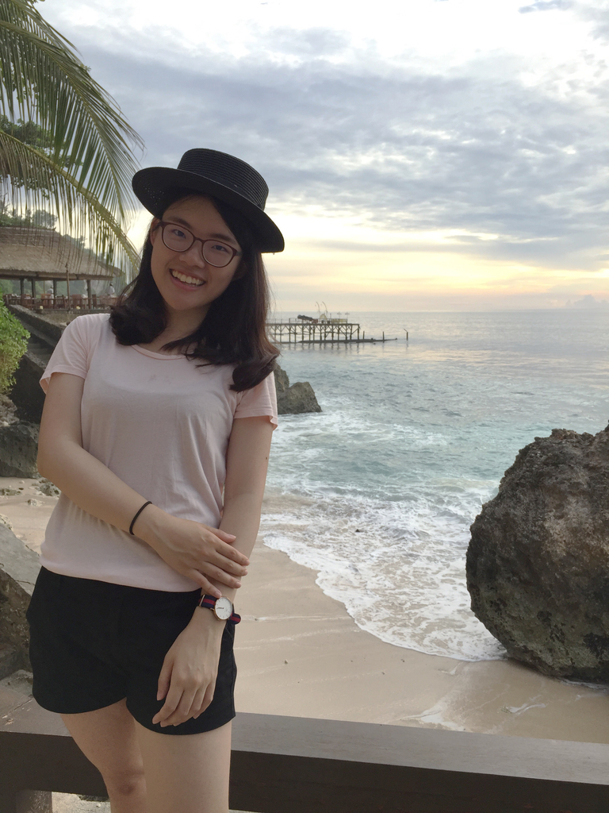

## 1.1 Introduction to R

### Expression

#### 每一段指令都是一個 expression

#### 輸入有效的 expression 後，R 會執行並且把結果呈現於 Console 中

##### eg1. 1 + 1

##### eg2. ?sum

### Assignment

#### 一般給 R 的指令不是一個 expression 就是一個 assignment

#### 物件(object)被 assign 過後，會陳列於 Environment 中

#### 物件可以是變數、數字、文字、向量、函數或更複雜的東西

##### eg1. x <- 1 + 1 (建議寫法)

##### eg2. y = c(1,2,3)

## 1.2 基本數學運算

- 加減乘除

```r
> 1 + 3   # 加
```

```
[1] 4
```

```r
> 10 - 8  # 減
```

```
[1] 2
```

```r
> 3 * 2   # 乘
```

```
[1] 6
```

```r
> 6 / 3   # 除
```

```
[1] 2
```

- 次方、立方、平方根

```r
> 3 ^ 2       # 3的平方
```

```
[1] 9
```

```r
> 3 ^ 3       # 3的立方
```

```
[1] 27
```

```r
> 3 ** 2      # 3的平方
```

```
[1] 9
```

```r
> sqrt(4)     # 4的平方根
```

```
[1] 2
```

```r
> 4 ^ (1/2)   # 4的平方根
```

```
[1] 2
```

- exponential

```r
> exp(10)     # e = 2.71828... ; 指e ^10
```

```
[1] 22026.47
```

- log

```r
> log(10)     # 以e為底取log
```

```
[1] 2.302585
```

```r
> log(10,2)   # 以2為底取log ; log(x,base)
```

```
[1] 3.321928
```

```r
> log2(10)    # log2代表以2為底
```

```
[1] 3.321928
```

```r
> log10(10)   # log10代表以10為底
```

```
[1] 1
```

- 小數位數取捨

```r
> round(4.7)        # 四捨五入
```

```
[1] 5
```

```r
> round(4.786, 2)   # 四捨五入到小數點第二位
```

```
[1] 4.79
```

```r
> floor(4.7)        # 無條件捨去
```

```
[1] 4
```

```r
> ceiling(4.7)      # 無條件進位
```

```
[1] 5
```

```r
> abs(-4.7)         # 取絕對值
```

```
[1] 4.7
```

## Chapter 2 - Vectors

## Chapter 2 - Vectors

##### 2.1 向量的類別

##### 2.2 向量的運算

##### 2.3 變數的賦值

##### 2.4 變數種類的轉換

## Vectors

#### 在 R 中，每一樣**東西**，都叫做**物件**

#### R 物件最基本的單位是向量(Vectors)

#### 以c()呈現向量，向量中的元素以逗號分隔

#### eg. c(1, 2, 3) 為一包含元素1, 2, 3的向量

```r
> c( 1 , 2 , 3 )
```

```
[1] 1 2 3
```

## 2.1 向量的類別

- (1). 數值向量(numeric vector)

```r
> class(c( 1 , 2 , 3 ))
```

```
[1] "numeric"
```

- (2). 字串向量(character vector)

```r
> class(c("我是00","他是閔閔"))
```

```
[1] "character"
```

- (3). 布林向量(logical vector)

```r
> class( c( TRUE, FALSE) )
```

```
[1] "logical"
```

- 種類有順序之分  
  Character > Numeric > Logical

```r
> class(c('A',1))
```

```
[1] "character"
```

```r
> class(c('B',T))
```

```
[1] "character"
```

```r
> class(c(1,T))
```

```
[1] "numeric"
```

- (4). Factor
  - 有LEVEL的設定

```r
> x <- c("A","B","A")
> factor(x)
```

```
[1] A B A
Levels: A B
```

```r
> factor(x,levels = c(x[2],x[1]))
```

```
[1] A B A
Levels: B A
```

## 2.2 向量的運算

#### **Vectors**

- 在 R 中，大部份的運算都是向量式的
- 當多組向量在進行運算時，會由相對應位置的元素進行運算
- 當向量長度不同時，R 會重複較短的向量，補足至與較長向量長度一樣

請觀察以下向量運算的程式碼，並且腦海想像一下結果為何？

```r
> # eg1
> c(1, 2, 3) + c(1, 2, 3)
> # eg2
> 1 + c(1, 2, 3)
> # eg3
> c(1, 2) + c(1, 2, 3)
> # eg4
> c(1, 2) + c(1, 2, 3, 4)
```

## Vectors (Cont.)

```r
> c(1, 2, 3) + c(1, 2, 3)
```

```
[1] 2 4 6
```

```r
> 1 + c(1, 2, 3)
```

```
[1] 2 3 4
```

```r
> c(1, 2) + c(1, 2, 3)
```

```
[1] 2 4 4
```

```r
> c(1, 2) + c(1, 2, 3, 4)
```

```
[1] 2 4 4 6
```

## 2.3 變數的賦值

- (a). 種類一致的狀況

```r
> x <- c(1,2,3)
> y <- c(4,5,6)
```

```r
> x+y
```

```
[1] 5 7 9
```

```r
> x*y
```

```
[1]  4 10 18
```

```r
> x/y
```

```
[1] 0.25 0.40 0.50
```

- (b). 種類不一致的狀況
  - Note : Character > Number > Logical

```r
> x <- c(1,2,'a')
> class(x)
```

```
[1] "character"
```

```r
> y <- c(1,2,TRUE)
> class(y)
```

```
[1] "numeric"
```

```r
> z <- c('a',1,TRUE)
> class(z)
```

```
[1] "character"
```

## 2.4 變數種類的轉換

有時候資料並非為我們預想中的資料型態，因此我們需要做轉換

- (a). as.character
  - 轉成character型態

```r
> x <- c(1,2,3)
> as.character(x)
```

```
[1] "1" "2" "3"
```

- (b). as.numeric
  - 轉成numeric型態
  - 若轉換過去沒有對應到數字則會出現NA
  - 注意factor ==> numeric

```r
> x <- c('1','2')
> as.numeric(x)
```

```
[1] 1 2
```

```r
> y <- c('1','a')
> as.numeric(y)
```

```
[1]  1 NA
```

```r
> z <- factor(c('a','b','c'))
> as.numeric(z)
```

```
[1] 1 2 3
```

```r
> z1 <- factor(c('a','b','c'),levels=c('c','b','a'))
> as.numeric(z1)
```

```
[1] 3 2 1
```

```r
> w <- factor(c('4','5','6'))
> as.numeric(w)
```

```
[1] 1 2 3
```

##### *注意：若是要由factor轉為numeric，須先轉成character再轉成numeric*

```r
> w <- factor(c('4','5','6'))
> as.numeric( as.character(w) )
```

```
[1] 4 5 6
```

## Chapter 3 - 物件

## Chapter 3 - 物件

##### 3.1 Matrix

##### 3.2 Data frame

##### 3.3 Lists

##### 3.4 取變數

##### 3.5 特別的元素

##### 3.6 物件的賦值

## 物件

- 物件除了最簡單的向量 (Vectors) 形式外  
  也可以是矩陣 (matrix)，列表 (Lists)，或 資料框架 (data frames) 等  
  簡單來說就是用來儲存一大堆**變數(向量)**的東西

## 3.1 Matrix

- Matrix如同線性代數中學的，有列有行，存放一定是`數值`
- Matrix可以由一長串的向量去轉換而成，告訴他維度即可

```r
> ## 1~9的打法可以打 :
> ## == 是用來判斷有沒有相等
> 1:9 == c(1,2,3,4,5,6,7,8,9)
```

```
[1] TRUE TRUE TRUE TRUE TRUE TRUE TRUE TRUE TRUE
```

```r
> matrix(c(1:9),nrow=3)
```

```
     [,1] [,2] [,3]
[1,]    1    4    7
[2,]    2    5    8
[3,]    3    6    9
```

```r
> matrix(c(1:9),nrow=3,ncol=3) # same
```

```
     [,1] [,2] [,3]
[1,]    1    4    7
[2,]    2    5    8
[3,]    3    6    9
```

```r
> matrix(c(1:9),nrow=3,byrow = T)
```

```
     [,1] [,2] [,3]
[1,]    1    2    3
[2,]    4    5    6
[3,]    7    8    9
```

```r
> # 矩陣相乘
> matrix(c(1:4),nrow=2,byrow = T) %*% matrix(c(5:8),nrow=2,byrow = T)
```

```
     [,1] [,2]
[1,]   19   22
[2,]   43   50
```

```r
> # 相對應元素相乘
> matrix(c(1:4),nrow=2,byrow = T) * matrix(c(5:8),nrow=2,byrow = T)
```

```
     [,1] [,2]
[1,]    5   12
[2,]   21   32
```

## 3.2 Data frame

- Data.frame內存放一大堆變數(向量), 變數間型態可以不同
- 限制：變數間長度必須一樣

```r
> data <- data.frame(x1=c(1,2,3), #若要換行則此逗號要擺這
+                    x2=c('a','b','c'))
> data
```

```
  x1 x2
1  1  a
2  2  b
3  3  c
```

```r
> data <- data.frame(x1=c(1,2,3,4),
+                    x2=c('a','b','c'))
```

```
Error in data.frame(x1 = c(1, 2, 3, 4), x2 = c("a", "b", "c")): arguments imply differing number of rows: 4, 3
```

## 3.3 Lists

- 彈性較大的物件，想像成一種Data.frame，但允許變數長度不同
- Data.frame 為 List 的一種特例: 長度相同

```r
> lst <- list(list1=c(1:5),
+             list2=c('a','b'))
> lst
```

```
$list1
[1] 1 2 3 4 5

$list2
[1] "a" "b"
```

## 3.4 取變數

- 想像以上物件是一個很大的衣櫃，變數(向量)就是衣櫃裡的所有的抽屜  
  你可以自行選取你要從衣櫃中取出哪些抽屜，元素可以看成抽屜裡的衣服
- Data frame取值
  - 利用`[i,j]` 來對 dataframe 進行取值的動作，其中， `i 為列數`、 `j 為行數`
  - `[i,]` 表示取出 dataframe 中`第 i 列的所有資料`，包含所有行變數
  - `[,j]` 表示取出 dataframe 中`第 j 行的所有資料`，包含所有列資料
  - `$` (錢字號)這裡可以用來`挑選特定欄位`！記得搭配`tab鍵`讓你事半功倍！

```r
> data <- data.frame(Date=c('7/23','7/23'),
+                    Come=c(T,F),
+                    Time=c(3,6))
```

```r
> ## 好，我要從Data中取出日期的變數(欄位、向量、抽屜)
> data$Date
```

```
[1] 7/23 7/23
Levels: 7/23
```

```r
> data[,1]
```

```
[1] 7/23 7/23
Levels: 7/23
```

```r
> ## 好，我要從Data中取出是否會來的變數(欄位、向量、抽屜)
> data$Come
```

```
[1]  TRUE FALSE
```

```r
> data[,2]
```

```
[1]  TRUE FALSE
```

- Lists取值
  - [i]：取出 list 中的第 i 個物件，`注意！取出來的物件依舊是 list 結構！`
  - [[i]]：取出第 i 個物件中的全部元素，`注意！[[]]會破壞原本的 list 結構！`
  - [[i]][j]：取出第 i 個物件中的第j個元素
  - 若物件已命名，可以利用 `$` (錢字號)來提取物件

```r
> ## List
> data <- list(Date=c('7/23','7/24','7/25','7/26'),
+                    Come=c(T,F),
+                    Time=c(3,6))
```

```r
> ## 好，我要從Data中取出日期的變數(欄位、向量、抽屜)
> ## 只是今天衣櫃的每個抽屜長度可以不一樣
> data$Date
```

```
[1] "7/23" "7/24" "7/25" "7/26"
```

```r
> data[1]
```

```
$Date
[1] "7/23" "7/24" "7/25" "7/26"
```

```r
> data[[1]]
```

```
[1] "7/23" "7/24" "7/25" "7/26"
```

```r
> data[[1]][2]
```

```
[1] "7/24"
```

## 3.5 特別的元素

- (a). NA
  - 未來資料中一定常常碰到NA

```r
> ## NA常常就像這樣任性的存在
> x <- c(1,2,3,NA,5)
> y <- c(1,2,NA,4,5)
```

```r
> ## NA只要碰到加減乘除就會爆炸
> x + y
```

```
[1]  2  4 NA NA 10
```

```r
> mean(x)
```

```
[1] NA
```

```r
> ## 只要把缺憾移除掉人生就美好多了
> mean(x,na.rm=T)
```

```
[1] 2.75
```

```r
> ## 通常NA有規則可以填補我們就會補起來
> x[4] <- 4
```

```r
> ## 但往往你需要更聰明的方式去補而不是這樣傻傻的數啊 ！！
> ## is.na可以回傳變數哪一個位置為NA
> is.na(y)
```

```
[1] FALSE FALSE  TRUE FALSE FALSE
```

```r
> y[ is.na(y) ] <- 3
```

- (b). Inf

```r
> my.money <- c(0,100,Inf)
> your.money <- c(-Inf,10,0)
```

```r
> my.money+your.money
```

```
[1] -Inf  110  Inf
```

```r
> my.money/your.money ## 我也不知道為什麼 Inf/0會=Inf，可能要問問助教
```

```
[1]   0  10 Inf
```

- (c). NaN
  - **N**ot a **N**umber

```r
> 0/0
```

```
[1] NaN
```

```r
> 1/0-1/0
```

```
[1] NaN
```

## 3.6 物件的賦值

- 一切從賦值開始
  - 賦值讓我們把物件儲存在記憶體裡面，隨時可以取用

```r
> data <- data.frame(name=c('閔閔','安安','筠筠'),
+                    deg=c('人生勝利組','首席工程師','團花'),
+                    pro=c(60,90,85),
+                    stringsAsFactors = F) #此case,不要讓字串別成factor
```

```r
> data
```

```
  name        deg pro
1 閔閔 人生勝利組  60
2 安安 首席工程師  90
3 筠筠       團花  85
```

- (a). 新增變數、刪除變數

```r
> data$win <- c(F,T,T) ## Or 前面教過的另一種 data[,4] <- c(F,T,T)
> data
```

```
  name        deg pro   win
1 閔閔 人生勝利組  60 FALSE
2 安安 首席工程師  90  TRUE
3 筠筠       團花  85  TRUE
```

```r
> data$win <- NULL ## Or 前面教過的另一種 data <- data[,-4]
> data
```

```
  name        deg pro
1 閔閔 人生勝利組  60
2 安安 首席工程師  90
3 筠筠       團花  85
```

- (b). 新增列、刪除列

```r
> data[4,] <- c('00','不好說',0)
> data
```

```
  name        deg pro
1 閔閔 人生勝利組  60
2 安安 首席工程師  90
3 筠筠       團花  85
4   00     不好說   0
```

```r
> data <- data[-3,]
> data
```

```
  name        deg pro
1 閔閔 人生勝利組  60
2 安安 首席工程師  90
4   00     不好說   0
```

- (c). 挑選列、挑選變數

```r
> ## 我們要的並非只是回傳T or F，而是要整個資料阿！！！！
> data$pro > 50
```

```
[1]  TRUE  TRUE FALSE
```

```r
> ## 把T or F 放進 之前教過的[]裡面，他就會乖乖的挑選符合條件的資料出來摟
> data[ data$pro > 50, ]
```

```
  name        deg pro
1 閔閔 人生勝利組  60
2 安安 首席工程師  90
```

```r
> ## 挑選變數的部分跟之前一樣！
> data$pro  ## or data[,3]
```

```
[1] "60" "90" "0"
```

- (d). rbind、cbind
  - rbind()：上下合併 (列合併)
  - cbind()：左右合併 (行合併)

```r
> # 將向量c(1, 2, 3)與向量c(4, 5, 6)上下合併
> rbind(c(1, 2, 3), c(4, 5, 6))
```

```
     [,1] [,2] [,3]
[1,]    1    2    3
[2,]    4    5    6
```

```r
> # 將向量c(1, 2, 3)與向量c(4, 5, 6)左右合併
> cbind(c(1, 2, 3), c(4, 5, 6))
```

```
     [,1] [,2]
[1,]    1    4
[2,]    2    5
[3,]    3    6
```

## Chapter 4 - 流程控制

## Chapter 4 - 流程控制

##### 4.1 邏輯判斷

##### 4.2 if else

##### 4.3 迴圈結構

## 4.1 邏輯判斷

- 以下介紹常用的邏輯判斷符號
  - **<**、**>** ： 小於、大於。
  - **<=**、**>=** ： 小於等於、大於等於。
  - **==** ： 等於。
  - **!=** ： 不等於。
  - **&** ： 交集（且）。
  - **|** ： 聯集（或）。
  - A **%in%** B ： A是否在B內。

```r
> 3 > 2
```

```
[1] TRUE
```

```r
> 3 < 2
```

```
[1] FALSE
```

```r
> 3 >= 5
```

```
[1] FALSE
```

```r
> 3 <= 5
```

```
[1] TRUE
```

```r
> 2 == 3
```

```
[1] FALSE
```

```r
> 2 != 3
```

```
[1] TRUE
```

```r
> c(1:3) >= c(3:1)
```

```
[1] FALSE  TRUE  TRUE
```

```r
> T & T
```

```
[1] TRUE
```

```r
> T & F
```

```
[1] FALSE
```

```r
> T | F
```

```
[1] TRUE
```

```r
> c(2,5,3) %in% c(1:3)
```

```
[1]  TRUE FALSE  TRUE
```

## 4.2 if else

- ifelse簡易語法
  - ifelse(條件式, A(TRUE) , B(FALSE) )  
    如果條件式判斷為TRUE，則為A  
    如果條件式判斷為FALSE，則為B

```r
> ifelse( 3 > 2 , 3 + 2 , 3 - 2 ) #如果3>2成立，則執行3+2，否則執行3-2
```

```
[1] 5
```

- 條件執行
  - if A條件式  
    {A條件式判斷為TRUE，則執行此區塊}  
    else if B條件式  
    {A條件式判斷為FALSE，且B條件式判斷為TRUE，則執行此區塊}  
    else  
    {A條件式和B條件式皆判斷為FALSE，則執行此區塊}

```r
> if(3 < 2){
+   3 + 2               # 如果 "3 < 2" 為TRUE，則執行3 + 2
+ }else if (3 == 2){
+   3 * 2               # 否則如果 "3 == 2" 為TRUE，則執行3 * 2
+ }else{
+   3 - 2               # 如果 "3 < 2"和 "3 == 2" 皆為FALSE，則執行3 - 2
+ }
```

```
[1] 1
```

## 4.3 迴圈結構

- for迴圈

```r
> x <- 0
> for(i in 1:5){
+   x <- x + i
+   print(x)
+ }
```

```
[1] 1
[1] 3
[1] 6
[1] 10
[1] 15
```

```r
> cumsum(1:5)    # cumsum : 累加
```

```
[1]  1  3  6 10 15
```

## Chapter 5 - 常用的function

- (a). ?in R
  - 忘記一個function的用法時常常用?來查詢  
    或是用help()

```r
> ?mean
> help(mean)
```

- (b). length
  - 看一個向量長度時常用length

```r
> length(c(1:10))
```

```
[1] 10
```

- (c). names
  - 資料行名稱

```r
> score <- c(10,20,100)
> names(score) <- c('SAS','SPSS','R')
> score
```

```
 SAS SPSS    R
  10   20  100
```

- (d). sort, order
  - sort：產生一組長度一樣的向量，將向量中的元素由小到大排列
  - order：產生一組長度一樣的向量，回傳排序後的元素在原向量的等級

```r
> sort( c(1,5,2) )
```

```
[1] 1 2 5
```

```r
> order( c(1,5,2) )
```

```
[1] 1 3 2
```

- (e). seq, rep
  - seq()：可以生成連續整數的向量
  - rep()：可以重複一個數字或一組序列向量

```r
> seq(from = 1, to = 9, by = 2) ## seq(1,9,2)
```

```
[1] 1 3 5 7 9
```

```r
> seq(from = 9, to = 1, by = -2) ## seq(9,1,-2)
```

```
[1] 9 7 5 3 1
```

```r
> rep( seq(from = 1, to = 9, by = 2) , times= 2)
```

```
 [1] 1 3 5 7 9 1 3 5 7 9
```

```r
> rep( seq(from = 1, to = 9, by = 2) , each= 2)
```

```
 [1] 1 1 3 3 5 5 7 7 9 9
```

- (f). 自定function
  - 有時候我們會需要自定一個function來完成某些事情  
    這邊教大家如何寫一個自己的function  
    假設我們沒有算平均數的function，我們要自己寫一個

```r
> cust.mean <- function(x){
+   mean.result <- sum(x)/length(x)
+   return(mean.result)
+ }
>
> cust.mean(1:10)
```

```
[1] 5.5
```

```r
> ## It's same
> mean(1:10)
```

```
[1] 5.5
```

- (g). which
  - which是一個很常用的function  
    which可以理解為：哪一個為TURE  
    which更常拿來挑選資料

```r
> which(c(1:3)==3)
```

```
[1] 3
```

```r
> which(c(F,F,T))
```

```
[1] 3
```

```r
> data
```

```
  name        deg pro
1 閔閔 人生勝利組  60
2 安安 首席工程師  90
4   00     不好說   0
```

```r
> which(data$name=='閔閔')
```

```
[1] 1
```

```r
> ## 挑選資料列
> row <- which(data$name=='閔閔')
> data[row,]
```

```
  name        deg pro
1 閔閔 人生勝利組  60
```

- (h). 字串處理
  - nchar(長度), substr(擷取), paste(剪貼), strsplit(分割)
  - 字串常常是很棘手的難題  
    例如：台北市文山區指南路三段….  
    也許我們想保留的只有台北市文山區或是指南路三段  
    這時候就會對字串做些處理

```r
> x <- c('Apple-iphone','Samsung-Note','HTC-wtf')
```

```r
> ## 計算字數
> nchar(x)
```

```
[1] 12 12  7
```

```r
> strsplit(x, split = '-') ## 切割品牌跟手機型號
```

```
[[1]]
[1] "Apple"  "iphone"

[[2]]
[1] "Samsung" "Note"

[[3]]
[1] "HTC" "wtf"
```

```r
> substr(x = x[1] , start = 1 , stop = 5) ## 字串的擷取
```

```
[1] "Apple"
```

```r
> paste(substr(x[2],1,7),substr(x[3],5,7), sep = '-') ## 字串的剪貼
```

```
[1] "Samsung-wtf"
```

## Chapter 6 - 資料處理分析

## Chapter 6 - 資料處理分析

##### 6.1 設定R工作環境

##### 6.2 讀取資料

##### 6.3 Data frame操作

## 6.1 設定R工作環境

- 查詢工作目錄 (get working directory)
  - getwd:看目前工作目錄在哪裡

```r
> getwd()
```

```
[1] "/Users/hsiaoling/Desktop/Code/Program/Workshop"
```

- 設定工作目錄 (set working directory)
  - setwd:直接手動設定工作目錄

```r
> # Windows
> setwd("C:/Users")
> setwd("C:\\Users")
>
> # Mac
> setwd("/Users/hsiaoling/Desktop")
```

## 6.2 讀取資料

- (a). csv file
  - write.csv：匯出csv檔
  - read.csv：讀入csv檔

```r
> demo <- iris
```

```r
> # 直接將demo.csv存至剛剛設定的工作目錄
> write.csv(demo,"demo.csv")
>     ## or
> # 將demo.csv存至指定路徑
> write.csv(demo,"/Users/hsiaoling/Desktop/Code/Program/Workshop/demo.csv")
```

```r
> # 將剛剛匯出的demo.csv檔讀進來
> data <- read.csv("/Users/hsiaoling/Desktop/Code/Program/Workshop/demo.csv")
>     # or
> data <- read.csv(file.choose())
```

- (b). read.table
  - header：第一列是否為資料行名稱
  - sep：行與行之間以什麼做分割（csv為以 **,** 做區隔）

```r
> data <- read.table("/Users/hsiaoling/Desktop/Code/Program/Workshop/demo.csv",
+                    header = T,sep = ',')
```

- (c). scan
  - 連續輸入數字，  
    按一次enter鍵可以輸入下一筆數字，  
    連按兩次enter將結束輸入。

```r
> s <- scan()
```

```
> s <- scan()
1: 5
2: 4
3: 0
4: 0
5:
Read 4 items

> s
[1] 5 4 0 0
```

## 文字編碼問題

- Mac-utf8 讀取 windows-big5編碼

```r
> data <- read.csv("demo.csv",fileEncoding = 'big5')
```

- windows-big5 讀取 Mac-utf8 編碼

```r
> data <- read.csv("demo.csv",fileEncoding = 'utf8')
```

## 6.3 Data frame操作

- (1). 先載入一個data.frame來玩玩
  - 萬用的iris資料 ： 關於花的故事
  - Sepal : 萼片
  - Petal : 花瓣

```r
> data(iris)
```

- (2). 首先簡單了解一下資料長相
  - head ： 看前幾筆資料
  - tail ： 看末幾筆資料
  - str ：看資料的結構

```r
> head(iris)
```

```
  Sepal.Length Sepal.Width Petal.Length Petal.Width Species
1          5.1         3.5          1.4         0.2  setosa
2          4.9         3.0          1.4         0.2  setosa
3          4.7         3.2          1.3         0.2  setosa
4          4.6         3.1          1.5         0.2  setosa
5          5.0         3.6          1.4         0.2  setosa
6          5.4         3.9          1.7         0.4  setosa
```

```r
> tail(iris)
```

```
    Sepal.Length Sepal.Width Petal.Length Petal.Width   Species
145          6.7         3.3          5.7         2.5 virginica
146          6.7         3.0          5.2         2.3 virginica
147          6.3         2.5          5.0         1.9 virginica
148          6.5         3.0          5.2         2.0 virginica
149          6.2         3.4          5.4         2.3 virginica
150          5.9         3.0          5.1         1.8 virginica
```

```r
> str(iris)
```

```
'data.frame':   150 obs. of  5 variables:
 $ Sepal.Length: num  5.1 4.9 4.7 4.6 5 5.4 4.6 5 4.4 4.9 ...
 $ Sepal.Width : num  3.5 3 3.2 3.1 3.6 3.9 3.4 3.4 2.9 3.1 ...
 $ Petal.Length: num  1.4 1.4 1.3 1.5 1.4 1.7 1.4 1.5 1.4 1.5 ...
 $ Petal.Width : num  0.2 0.2 0.2 0.2 0.2 0.4 0.3 0.2 0.2 0.1 ...
 $ Species     : Factor w/ 3 levels "setosa","versicolor",..: 1 1 1 1 1 1 1 1 1 1 ...
```

- (3). 開始操作data.frame物件
  - 想像你現在已經有了一個衣櫥了，開始把玩抽屜的部份
  - 複習data.frame

先看一下Species這個變數，個數皆是50個  
table函式可以讓我們看次數分配，記得塞給他一個以上的向量

```r
> table(iris$Species)
```

```
    setosa versicolor  virginica
        50         50         50
```

也許有時候是想看比例 : prop.table

```r
> iris.table <- table(iris$Species)
> prop.table(iris.table)
```

```
    setosa versicolor  virginica
 0.3333333  0.3333333  0.3333333
```

summary可以讓我們了解物件或是變數的敘述統計量

```r
> summary(iris)
```

```
  Sepal.Length    Sepal.Width     Petal.Length    Petal.Width          Species
 Min.   :4.300   Min.   :2.000   Min.   :1.000   Min.   :0.100   setosa    :50
 1st Qu.:5.100   1st Qu.:2.800   1st Qu.:1.600   1st Qu.:0.300   versicolor:50
 Median :5.800   Median :3.000   Median :4.350   Median :1.300   virginica :50
 Mean   :5.843   Mean   :3.057   Mean   :3.758   Mean   :1.199
 3rd Qu.:6.400   3rd Qu.:3.300   3rd Qu.:5.100   3rd Qu.:1.800
 Max.   :7.900   Max.   :4.400   Max.   :6.900   Max.   :2.500
```

再來看看Sepal.Length這個變數

```r
> summary(iris$Sepal.Length)
```

```
   Min. 1st Qu.  Median    Mean 3rd Qu.    Max.
  4.300   5.100   5.800   5.843   6.400   7.900
```

想要改變長度寬度的單位(加減乘除都行)

```r
> iris$Sepal.Length <- iris$Sepal.Length*10
> summary(iris$Sepal.Length)
```

```
   Min. 1st Qu.  Median    Mean 3rd Qu.    Max.
  43.00   51.00   58.00   58.43   64.00   79.00
```

想要單獨算Petal.Width的平均數以及標準差

```r
> mean(iris$Petal.Width)
```

```
[1] 1.199333
```

```r
> sd(iris$Petal.Width)
```

```
[1] 0.7622377
```

想要新增一個變數為Sepal.Length/Sepal.Width  
利用$幫助你開新的一個抽屜！後面接的名字即是新抽屜的名字

```r
> iris$mary <- iris$Sepal.Length/iris$Sepal.Width
> head(iris)
```

```
  Sepal.Length Sepal.Width Petal.Length Petal.Width Species     mary
1           51         3.5          1.4         0.2  setosa 14.57143
2           49         3.0          1.4         0.2  setosa 16.33333
3           47         3.2          1.3         0.2  setosa 14.68750
4           46         3.1          1.5         0.2  setosa 14.83871
5           50         3.6          1.4         0.2  setosa 13.88889
6           54         3.9          1.7         0.4  setosa 13.84615
```

覺得Sepal.Length那些欄位名字太長了，想要改名稱！  
利用colnames函式：

```r
> colnames(iris)[1:4] <- c('S.L','S.W','P.L','P.W')
> head(iris)
```

```
  S.L S.W P.L P.W Species     mary
1  51 3.5 1.4 0.2  setosa 14.57143
2  49 3.0 1.4 0.2  setosa 16.33333
3  47 3.2 1.3 0.2  setosa 14.68750
4  46 3.1 1.5 0.2  setosa 14.83871
5  50 3.6 1.4 0.2  setosa 13.88889
6  54 3.9 1.7 0.4  setosa 13.84615
```

算Setosa種類的平均S.L  
method 1: Base::which  
method 2: Base::subset ==> ?subset

```r
> which(iris$Species=='setosa')
```

```
 [1]  1  2  3  4  5  6  7  8  9 10 11 12 13 14 15 16 17 18 19 20 21 22 23 24 25 26 27 28 29 30 31 32
[33] 33 34 35 36 37 38 39 40 41 42 43 44 45 46 47 48 49 50
```

```r
> setosa <- iris[which(iris$Species=='setosa'),]
> head(setosa)
```

```
  S.L S.W P.L P.W Species     mary
1  51 3.5 1.4 0.2  setosa 14.57143
2  49 3.0 1.4 0.2  setosa 16.33333
3  47 3.2 1.3 0.2  setosa 14.68750
4  46 3.1 1.5 0.2  setosa 14.83871
5  50 3.6 1.4 0.2  setosa 13.88889
6  54 3.9 1.7 0.4  setosa 13.84615
```

```r
> setosa <- subset(iris, Species=='setosa')
> head(setosa)
```

```
  S.L S.W P.L P.W Species     mary
1  51 3.5 1.4 0.2  setosa 14.57143
2  49 3.0 1.4 0.2  setosa 16.33333
3  47 3.2 1.3 0.2  setosa 14.68750
4  46 3.1 1.5 0.2  setosa 14.83871
5  50 3.6 1.4 0.2  setosa 13.88889
6  54 3.9 1.7 0.4  setosa 13.84615
```

但如果你今天要算各個種類的S.L平均，你想要更快的方式

apply家族：apply, tapply, lapply, sapply …

本課堂在此只介紹tapply

其他可以參考http://bryannotes.blogspot.tw/2014/06/r-applysapplylapply.html

tapply(要計算的y,依照什麼分組,利用什麼函式)

```r
> tapply(iris$S.L, iris$Species, mean)
```

```
    setosa versicolor  virginica
     50.06      59.36      65.88
```

```r
> tapply(iris$S.L, iris$Species, sum)
```

```
    setosa versicolor  virginica
      2503       2968       3294
```

```r
> tapply(iris$S.L, iris$Species, sd)
```

```
    setosa versicolor  virginica
  3.524897   5.161711   6.358796
```